# **Homework_Week4**

Shivani

# 1 Contents

1. Loading
2. Viewing
3. Filtering
4. Visualising
5. Some statistics
6. Conclusion

## 1.1 Loading

Installing ‘palmerpenguins’ package and loading into R

On glancing, the data is merely about 3 different penguin species - Adelie, Gentoo and Chinstrap, their bill length, depth, flipper length, sex and their body mass in different islands during the year 2007, 2008 and 2009.

## 1.2 Viewing

For the current analysis, let us deep dive into the data to reveal more details Using ‘class’ and ‘describe’ functions to try and identify any discrepancy in the data

```r
library(Hmisc)  #loading hmisc library
library(palmerpenguins)
#looking at the data
class(penguins)
```

```
## [1] "tbl_df"     "tbl"        "data.frame"
```

```r
describe(penguins) #summarising the data
```

```
## penguins
##
##  8  Variables      344  Observations
## --------------------------------------------------------------------------------
## species
##        n  missing distinct
##      344        0        3
##
## Value         Adelie Chinstrap    Gentoo
## Frequency        152        68       124
## Proportion     0.442     0.198     0.360
## --------------------------------------------------------------------------------
## island
##        n  missing distinct
##      344        0        3
##
## Value         Biscoe     Dream Torgersen
## Frequency        168       124        52
## Proportion     0.488     0.360     0.151
## --------------------------------------------------------------------------------
## bill_length_mm
##        n  missing distinct     Info     Mean      Gmd      .05      .10
##      342        2      164        1    43.92    6.274    35.70    36.60
##      .25      .50      .75      .90      .95
##    39.23    44.45    48.50    50.80    51.99
##
## lowest : 32.1 33.1 33.5 34   34.1, highest: 55.1 55.8 55.9 58   59.6
## --------------------------------------------------------------------------------
## bill_depth_mm
##        n  missing distinct     Info     Mean      Gmd      .05      .10
##      342        2       80        1    17.15    2.267     13.9     14.3
##      .25      .50      .75      .90      .95
##     15.6     17.3     18.7     19.5     20.0
##
## lowest : 13.1 13.2 13.3 13.4 13.5, highest: 20.7 20.8 21.1 21.2 21.5
## --------------------------------------------------------------------------------
## flipper_length_mm
##        n  missing distinct     Info     Mean      Gmd      .05      .10
##      342        2       55    0.999    200.9    16.03    181.0    185.0
##      .25      .50      .75      .90      .95
```

[output cut: 15 more lines]

```
##
## Value      female   male
## Frequency     165    168
## Proportion  0.495  0.505
## --------------------------------------------------------------------------------
## year
##        n  missing distinct     Info     Mean      Gmd
##      344        0        3    0.888     2008   0.8919
##
## Value       2007  2008  2009
## Frequency    110   114   120
## Proportion 0.320 0.331 0.349
##
## For the frequency table, variable is rounded to the nearest 0
## --------------------------------------------------------------------------------
```

From above table, looks like Year, species and island details are clear. However, some values are missing in rest of the columns.

## 1.3 Filtering

Removing missing values from the data using drop_na() function and filtering out Chinstrap species since we are focusing only on Adelie and Gentoo species for the current analysis.

```r
library(palmerpenguins)
library(knitr)
library(tidyverse)
penguins_filter <-
  #taking original data set
  penguins %>%
  #filtering out any values equal to NA
  drop_na(bill_depth_mm, bill_length_mm, flipper_length_mm, body_mass_g, sex) %>%
  #filtering to remove Chinstrap species from the data
  filter(species != "Chinstrap") %>%
  #converting factor to character
  mutate(species = as.character(species))
kable(head(penguins_filter))
```

| species | island | bill_length_mm | bill_depth_mm | flipper_length_mm | body_mass_g | sex | year |
| --- | --- | --- | --- | --- | --- | --- | --- |
| Adelie | Torgersen | 39.1 | 18.7 | 181 | 3750 | male | 2007 |
| Adelie | Torgersen | 39.5 | 17.4 | 186 | 3800 | female | 2007 |
| Adelie | Torgersen | 40.3 | 18.0 | 195 | 3250 | female | 2007 |
| Adelie | Torgersen | 36.7 | 19.3 | 193 | 3450 | female | 2007 |
| Adelie | Torgersen | 39.3 | 20.6 | 190 | 3650 | male | 2007 |
| Adelie | Torgersen | 38.9 | 17.8 | 181 | 3625 | female | 2007 |

## 1.4 Visualising

Now that the data is tidy (we have removed all the missing values) and selective to the Adelie and Gentoo species only, we can plot and check various trends.

### 1.4.1 flipper length vs species - a histogram

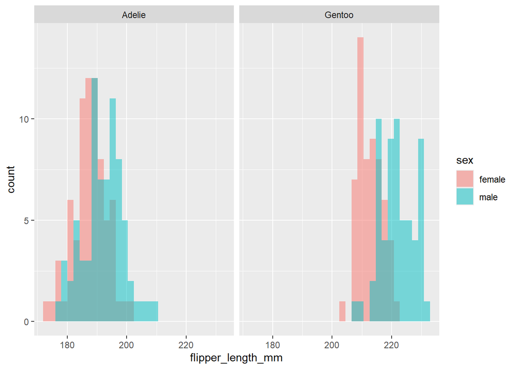

```r
ggplot(data = penguins_filter, aes(x = flipper_length_mm, fill=sex))+
  geom_histogram(alpha=0.5, position="identity") +
  facet_wrap(.~species)
```

Above plot is a basic comparison of flipper length between the two species. The differential colour in histogram represents the trend between males and females. Roughly, we could conclude that Adelie species have relatively smaller flipper lengths than that of the Gentoo. To get more insights, let’s check if these data are normally distributed.

## 1.5 Some statistics

### 1.5.1 An overlayed normal distribution over histogram

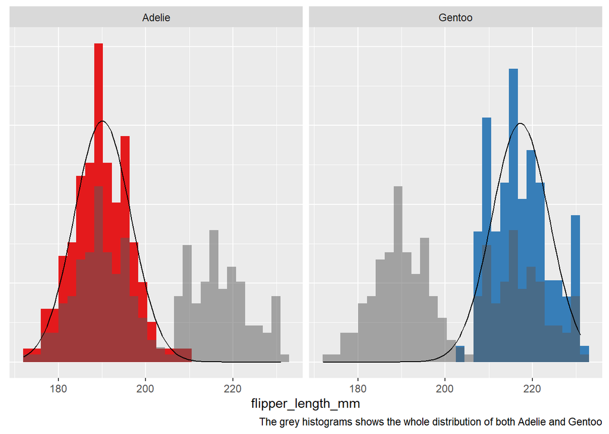

```r
#calculating mean and sd
d_summary <-
  penguins_filter %>%
  #split by species
  group_by(species) %>%
  #calculating mean and sd
  summarise(len_m = mean(flipper_length_mm, na.rm = T),
            len_sd = sd(flipper_length_mm, na.rm = T))

#creating a full distribution of data, without species difference
d2<-
  penguins_filter %>%
  #selecting data
  dplyr::select(-species)

#plotting
penguins_filter %>%
  ggplot() +
  aes() +
  #a histogram of penguins_filter data
  geom_histogram(aes(y = ..density.., x = flipper_length_mm, fill = species)) +
  #faceting by species
  facet_wrap(~ species) +
  #creating the histogram of the full data
  geom_histogram(data = d2, aes(y = ..density.., x = flipper_length_mm),
                 alpha = .5) +
  #calcualte the normal distrubution of Adelie and overlaying it
  stat_function(data = d_summary %>% filter(species == "Adelie"),
                fun = dnorm,
                args = list(mean = filter(d_summary,
                                          species == "Adelie")$len_m,
                            sd = filter(d_summary,
                                        species == "Adelie")$len_sd)) +
  #calcualte the normal distrubution of Gentoo and overlaying it
  stat_function(data = d_summary %>% filter(species == "Gentoo"),
                fun = dnorm,
                args = list(mean = filter(d_summary,
                                          species == "Gentoo")$len_m,
                            sd = filter(d_summary,
                                        species == "Gentoo")$len_sd)) +
  #setting appearance
  theme(legend.position = "none",
        axis.title.y = element_blank(),
        axis.text.y = element_blank(),
        axis.ticks.y = element_blank()) +
  labs(caption = "The grey histograms shows the whole distribution of both Adelie and Gentoo") +
  #colors
  scale_fill_brewer(type = "qual", palette = "Set1")
```

### 1.5.2 A qqplot

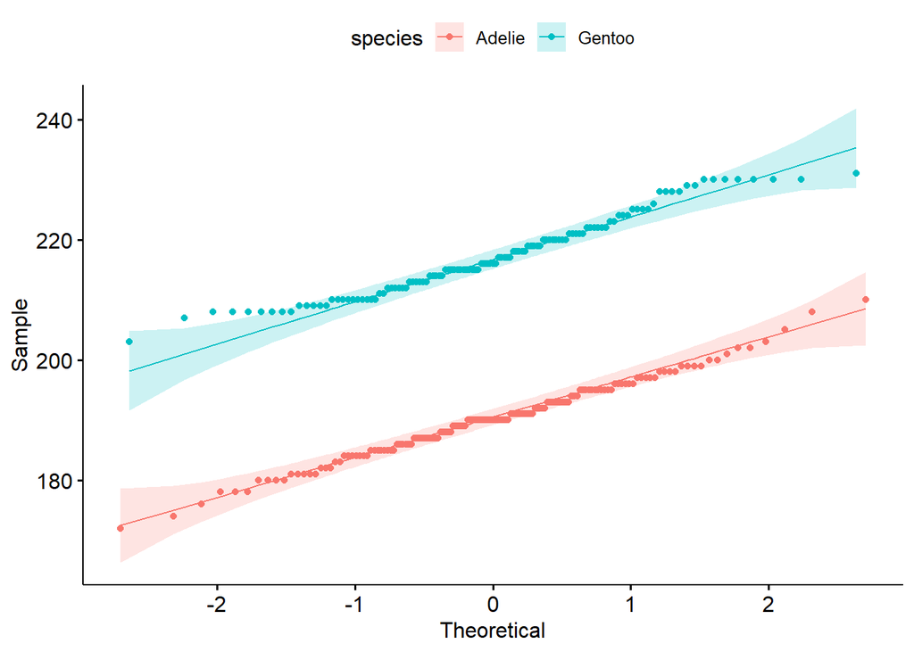

```r
library(ggpubr)
ggqqplot(penguins_filter, x="flipper_length_mm", color="species")
```

Above plots conclude that the flipper data for the two penguin species is normally distributed. Now we can apply statistical analysis to check our hypothesis. Let us assume: Null hypothesis(Ho) : There is no difference between the two species. Alternate hypothesis(Ha) : There is difference between the two species.

```r
library(rstatix) #using rstatix library
library(knitr)
t_test <- penguins_filter %>%
              t_test(flipper_length_mm~species, detailed=T) %>%
              #return the significances
              add_significance()
#print result
kable(t_test)
```

| estimate | estimate1 | estimate2 | .y. | group1 | group2 | n1 | n2 | statistic | p | df | conf.low | conf.high | method | alternative | p.signif |
| --- | --- | --- | --- | --- | --- | --- | --- | --- | --- | --- | --- | --- | --- | --- | --- |
| -27.13255 | 190.1027 | 217.2353 | flipper_length_mm | Adelie | Gentoo | 146 | 119 | -33.5055 | 0 | 251.3509 | -28.7274 | -25.53771 | T-test | two.sided | **** |

## 1.6 Conclusion

The obtained p-value is <<<0.05, which indicates that the results obtained are not entirely random, meaning there is likely a significant effect or difference. Hence we can reject our null hypothesis that states ‘There is no difference between the two species’.

[figure not shown]